# Homework 2

Molly Meyers

2025-11-10

# 1 Case:

Imagine you are the manager of a café. You need to attempt to maximize or maintain revenue while responding to changing market conditions, including a coffee surplus, a bread shortage, and the introduction of a new product (tea). Using transaction data and market basket analysis, you want to identify which items to promote, bundle, or adjust prices for, so that you can make data-driven decisions to maintain profitability.

The core problem is determining how to make strategic pricing and promotion decisions that protect overall revenue when external market forces push in different directions.

# 2 Load Packages

```r
library("plotly")
library("arules")
library("htmlwidgets")
library("ggplot2")
library("dplyr")
library("arulesViz")
```

# 3 Class Exercise Components

##Overview & Exploration of Data

```r
getwd()
```

```
## [1] "/Users/mollymeyers/Downloads/MBAn 556"
```

```r
transactions <- read.transactions(
  "/Users/mollymeyers/Downloads/StoreTransactions.csv",
  format = "single",
  sep = ",",
  cols = c("Transaction", "Item"),
  header = TRUE,
  rm.duplicates = TRUE)
```

###View and Summarize Data

```r
#remove none & NA first!
# remove literal "NA" or "none" items before plotting
transactions <- transactions[ , !(itemLabels(transactions) %in% c("NA", "NONE"))]

summary(transactions)
```

```
## transactions as itemMatrix in sparse format with
##  6613 rows (elements/itemsets/transactions) and
##  102 columns (items) and a density of 0.01977833
##
## most frequent items:
##  Coffee   Bread     Tea    Cake  Pastry (Other)
##    3188    2146     941     694     576    5796
##
## element (itemset/transaction) length distribution:
## sizes
##    0    1    2    3    4    5    6    7    8    9   10
##   37 2652 2155 1029  502  174   47   10    2    4    1
##
##    Min. 1st Qu.  Median    Mean 3rd Qu.    Max.
##   0.000   1.000   2.000   2.017   3.000  10.000
##
## includes extended item information - examples:
##                     labels
## 1               Adjustment
## 2 Afternoon with the baker
## 3                Alfajores
##
## includes extended transaction information - examples:
##   transactionID
## 1             1
## 2            10
## 3          1000
```

```r
#Results: Coffee, Bread, and Tea are top three items
```

### 3.0.1 First 10 Transactions

```r
inspect(transactions[1:10])
```

```
##      items                            transactionID
## [1]  {Bread}                          1
## [2]  {Medialuna, Scandinavian}        10
## [3]  {Chimichurri Oil, Scandinavian}  1000
## [4]  {Bread, Truffles}                1001
## [5]  {Brownie, Focaccia}              1002
## [6]  {Bread, Coffee}                  1003
## [7]  {Art Tray, Coffee, Cookies, Tea} 1004
## [8]  {Coffee}                         1005
## [9]  {Bread}                          1006
## [10] {Alfajores, Coffee, Coke}        1007
```

```r
# 4 of these transactions contain bread
# 4 of these transactions contain coffee
#Result: These products are likely "centers or gravity"
```

### 3.0.2 Visualization of Items

### 3.0.3 Filtered Items ≥5% Support

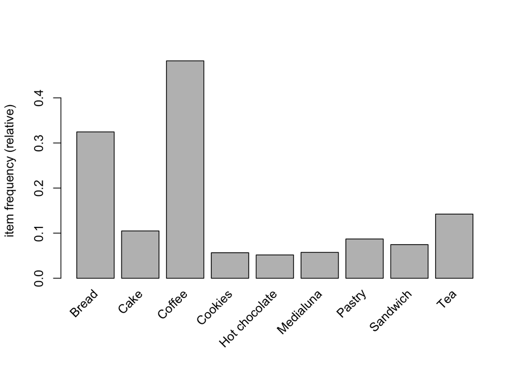

```r
#plot
# selecting support = .05, so that only items that appear in at least 5% of all transactions will be plotted
itemFrequencyPlot(transactions, support = .05)
```

Result: Coffee in particular is a center of gravity, which makes sense seeing as it’s a café. Bread is the second most common item, as illustrated in earlier summaries.

### 3.0.4 Top 20 Items accross Transactions

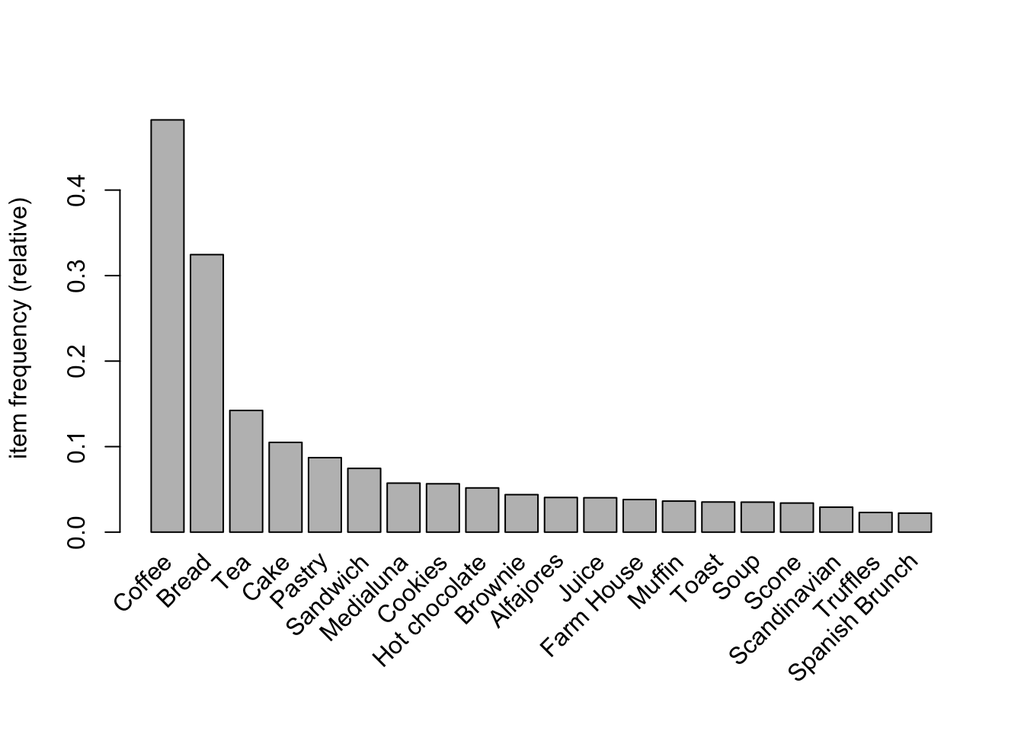

```r
#setting N=20, we see the top 20 items, alongside their support on the y axis
itemFrequencyPlot(transactions, topN=20)
```

## 3.1 Association Rules Model

```r
#train model
apriori(transactions)
```

```
## Apriori
##
## Parameter specification:
##  confidence minval smax arem  aval originalSupport maxtime support minlen
##         0.8    0.1    1 none FALSE            TRUE       5     0.1      1
##  maxlen target  ext
##      10  rules TRUE
##
## Algorithmic control:
##  filter tree heap memopt load sort verbose
##     0.1 TRUE TRUE  FALSE TRUE    2    TRUE
##
## Absolute minimum support count: 661
##
## set item appearances ...[0 item(s)] done [0.00s].
## set transactions ...[102 item(s), 6613 transaction(s)] done [0.00s].
## sorting and recoding items ... [4 item(s)] done [0.00s].
## creating transaction tree ... done [0.00s].
## checking subsets of size 1 2 done [0.00s].
## writing ... [0 rule(s)] done [0.00s].
## creating S4 object  ... done [0.00s].
```

```
## set of 0 rules
```

Result: No association rules were found because the default support and confidence thresholds were too high for this dataset, so no item combinations met the criteria.

```r
#set new support & confidence to see more rules
#lower support threshold, to hopefully encompass more transactions
## lower confidence, too high likely yields. 0 results
#number of 2 items in the list for rules
transactionrules <- apriori(transactions,
                            parameter = list(support = .006, confidence = .25, minlen = 2))
```

```
## Apriori
##
## Parameter specification:
##  confidence minval smax arem  aval originalSupport maxtime support minlen
##        0.25    0.1    1 none FALSE            TRUE       5   0.006      2
##  maxlen target  ext
##      10  rules TRUE
##
## Algorithmic control:
##  filter tree heap memopt load sort verbose
##     0.1 TRUE TRUE  FALSE TRUE    2    TRUE
##
## Absolute minimum support count: 39
##
## set item appearances ...[0 item(s)] done [0.00s].
## set transactions ...[102 item(s), 6613 transaction(s)] done [0.00s].
## sorting and recoding items ... [32 item(s)] done [0.00s].
## creating transaction tree ... done [0.00s].
## checking subsets of size 1 2 3 done [0.00s].
## writing ... [40 rule(s)] done [0.00s].
## creating S4 object  ... done [0.00s].
```

Result: Any item set appearing fewer than 39 times is ignored. No items were forced into the left-hand side (lhs) or right-hand side (rhs). Only 32 items met the minimum support threshold.

### 3.1.1 View Rules

```r
inspect(transactionrules)
```

```
##      lhs                      rhs      support     confidence coverage
## [1]  {Jammie Dodgers}      => {Coffee} 0.007258430 0.5161290  0.01406321
## [2]  {Salad}               => {Coffee} 0.007863300 0.6117647  0.01285347
## [3]  {Chicken Stew}        => {Coffee} 0.006048692 0.4123711  0.01466808
## [4]  {Mineral water}       => {Coffee} 0.006955996 0.4220183  0.01648269
## [5]  {Coke}                => {Coffee} 0.007107213 0.3430657  0.02071677
## [6]  {Tiffin}              => {Bread}  0.006048692 0.3125000  0.01935581
## [7]  {Tiffin}              => {Coffee} 0.010585211 0.5468750  0.01935581
## [8]  {Truffles}            => {Coffee} 0.008921821 0.3881579  0.02298503
## [9]  {Spanish Brunch}      => {Bread}  0.006048692 0.2721088  0.02222894
## [10] {Spanish Brunch}      => {Coffee} 0.014063209 0.6326531  0.02222894
## [11] {Scone}               => {Bread}  0.009375473 0.2755556  0.03402389
## [12] {Scone}               => {Coffee} 0.018448511 0.5422222  0.03402389
## [13] {Toast}               => {Coffee} 0.025706941 0.7296137  0.03523363
## [14] {Muffin}              => {Coffee} 0.017994859 0.4958333  0.03629215
```

[output cut: 67 more lines]

Result: Nearly 40 rules, all of which point toward primarily coffee, some bread, and one pointing to tea. maximum confidence displayed is .7296, which is really good for our case! it occurs with toast ==> coffee.

### 3.1.2 Summarize Rules

```r
summary(transactionrules)
```

```
## set of 40 rules
##
## rule length distribution (lhs + rhs):sizes
##  2  3
## 32  8
##
##    Min. 1st Qu.  Median    Mean 3rd Qu.    Max.
##     2.0     2.0     2.0     2.2     2.0     3.0
##
## summary of quality measures:
##     support           confidence        coverage            lift
##  Min.   :0.006049   Min.   :0.2543   Min.   :0.01028   Min.   :0.5742
##  1st Qu.:0.007825   1st Qu.:0.3333   1st Qu.:0.02038   1st Qu.:0.8504
##  Median :0.011568   Median :0.4326   Median :0.03455   Median :0.9750
##  Mean   :0.019352   Mean   :0.4408   Mean   :0.04675   Mean   :1.0038
##  3rd Qu.:0.023212   3rd Qu.:0.5397   3rd Qu.:0.05293   3rd Qu.:1.1272
##  Max.   :0.089823   Max.   :0.7296   Max.   :0.32451   Max.   :1.7872
##      count
##  Min.   : 40.00
##  1st Qu.: 51.75
##  Median : 76.50
##  Mean   :127.97
##  3rd Qu.:153.50
##  Max.   :594.00
##
## mining info:
##          data ntransactions support confidence
##  transactions          6613   0.006       0.25
##                                                                                            call
##  apriori(data = transactions, parameter = list(support = 0.006, confidence = 0.25, minlen = 2))
```

Results: Confidence measures look good across the board, ranging from 0.2543 to 0.7296, suggesting that many item pairs occur together consistently within this dataset. Support values are also fairly strong, ranging from a minimum of 0.006 to a maximum of 0.089, indicating that some item combinations appear in up to about 9% of all transactions.

## 3.2 Visualize Transaction Rules

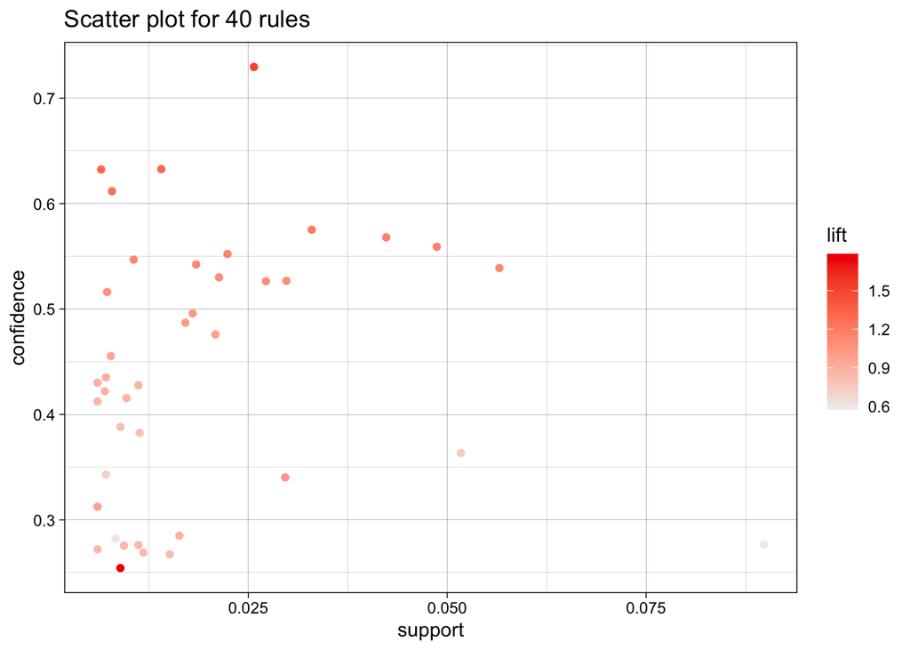

```r
plot(transactionrules)
```

## 3.3 First Ten Rules

```r
inspect(transactionrules[1:10])
```

```
##      lhs                 rhs      support     confidence coverage   lift
## [1]  {Jammie Dodgers} => {Coffee} 0.007258430 0.5161290  0.01406321 1.0706278
## [2]  {Salad}          => {Coffee} 0.007863300 0.6117647  0.01285347 1.2690088
## [3]  {Chicken Stew}   => {Coffee} 0.006048692 0.4123711  0.01466808 0.8553985
## [4]  {Mineral water}  => {Coffee} 0.006955996 0.4220183  0.01648269 0.8754101
## [5]  {Coke}           => {Coffee} 0.007107213 0.3430657  0.02071677 0.7116353
## [6]  {Tiffin}         => {Bread}  0.006048692 0.3125000  0.01935581 0.9629835
## [7]  {Tiffin}         => {Coffee} 0.010585211 0.5468750  0.01935581 1.1344054
## [8]  {Truffles}       => {Coffee} 0.008921821 0.3881579  0.02298503 0.8051719
## [9]  {Spanish Brunch} => {Bread}  0.006048692 0.2721088  0.02222894 0.8385162
## [10] {Spanish Brunch} => {Coffee} 0.014063209 0.6326531  0.02222894 1.3123384
##      count
## [1]  48
## [2]  52
## [3]  40
## [4]  46
## [5]  47
## [6]  40
## [7]  70
## [8]  59
## [9]  40
## [10] 93
```

For the first ten rules:

Support: Eight of the top ten rules display direction toward coffee, and the remaining two direct toward bread. Support is highest for Spanish Brunch to coffee (.014) suggesting this pairing is relatively common compared to others.. The lowest supports (0.006048692) occur with chicken stew to coffee, tiffin to bread, and spanish brunch to bread, indicating they’re less frequent but may still show meaningful purchasing patterns.

Lift: Lift values range from 0.71 to 1.31, showing that most item pairings with coffee or bread occur at or slightly above what would be expected by chance. Once again, the strongest association is Spanish Brunch ==> Coffee (1.31), meaning customers who buy Spanish Brunch are about 31% more likely to also buy coffee compared to random purchases. Other strong pairings include Salad ==> Coffee (1.27) and Tiffin ==> Coffee (1.13), both reinforcing coffee’s role as a common complement. Lower lift values (such as Coke ==> Coffee, 0.71) suggest weaker or a substitute relationships.

## 3.4 Improving Model Performance

We chose to maintain the set of rules generated with support = 0.006 and confidence = 0.25 because they produced a manageable number of 40 interpretable rules that reveal meaningful patterns in the café data. Many of the top rules show high confidence, indicating that these item pairings, particularly with coffee, are consistently purchased together. Sorting by confidence allows us to focus on the most reliable associations, which is especially important for our business goal: identifying items that are frequently bought with coffee so we can strategically adjust pricing to offset potential revenue losses from lowering coffee prices.

```r
#sorting trabsact rules by confidence
inspect(sort(transactionrules, by = "confidence", decreasing = TRUE)[1:20])
```

```
##      lhs                      rhs      support     confidence coverage
## [1]  {Toast}               => {Coffee} 0.025706941 0.7296137  0.03523363
## [2]  {Spanish Brunch}      => {Coffee} 0.014063209 0.6326531  0.02222894
## [3]  {Cake, Hot chocolate} => {Coffee} 0.006502344 0.6323529  0.01028278
## [4]  {Salad}               => {Coffee} 0.007863300 0.6117647  0.01285347
## [5]  {Medialuna}           => {Coffee} 0.032965371 0.5751979  0.05731136
## [6]  {Sandwich}            => {Coffee} 0.042340844 0.5679513  0.07455013
## [7]  {Pastry}              => {Coffee} 0.048691970 0.5590278  0.08710116
## [8]  {Alfajores}           => {Coffee} 0.022380160 0.5522388  0.04052624
## [9]  {Tiffin}              => {Coffee} 0.010585211 0.5468750  0.01935581
## [10] {Scone}               => {Coffee} 0.018448511 0.5422222  0.03402389
## [11] {Cake}                => {Coffee} 0.056555270 0.5389049  0.10494481
## [12] {Juice}               => {Coffee} 0.021321639 0.5300752  0.04022380
## [13] {Cookies}             => {Coffee} 0.029789808 0.5267380  0.05655527
## [14] {Hot chocolate}       => {Coffee} 0.027219114 0.5263158  0.05171632
```

[output cut: 27 more lines]

# 4 Scenario 1:

Coffee bean growers had a great year, leading to a surplus of coffee. To remain competitive, the café must lower coffee prices, which reduces revenue per cup. To maintain overall revenue, we want to identify which items are most frequently purchased before or alongside coffee.

By analyzing transactions, we can determine which products predict coffee purchases. These items can then be promoted or have their prices increased, helping to offset the revenue lost from lowering coffee prices.

##Create Coffee Rules

```r
## coffee is so prominent, that rather than testing different thresholds of metrics I will just maintain the metrics used iin transactions
coffeerules <- subset(transactionrules, rhs %in% "Coffee")
inspect(sort(coffeerules, by  = "confidence", decreasing = TRUE))
```

```
##      lhs                      rhs      support     confidence coverage
## [1]  {Toast}               => {Coffee} 0.025706941 0.7296137  0.03523363
## [2]  {Spanish Brunch}      => {Coffee} 0.014063209 0.6326531  0.02222894
## [3]  {Cake, Hot chocolate} => {Coffee} 0.006502344 0.6323529  0.01028278
## [4]  {Salad}               => {Coffee} 0.007863300 0.6117647  0.01285347
## [5]  {Medialuna}           => {Coffee} 0.032965371 0.5751979  0.05731136
## [6]  {Sandwich}            => {Coffee} 0.042340844 0.5679513  0.07455013
## [7]  {Pastry}              => {Coffee} 0.048691970 0.5590278  0.08710116
## [8]  {Alfajores}           => {Coffee} 0.022380160 0.5522388  0.04052624
## [9]  {Tiffin}              => {Coffee} 0.010585211 0.5468750  0.01935581
## [10] {Scone}               => {Coffee} 0.018448511 0.5422222  0.03402389
## [11] {Cake}                => {Coffee} 0.056555270 0.5389049  0.10494481
## [12] {Juice}               => {Coffee} 0.021321639 0.5300752  0.04022380
## [13] {Cookies}             => {Coffee} 0.029789808 0.5267380  0.05655527
## [14] {Hot chocolate}       => {Coffee} 0.027219114 0.5263158  0.05171632
```

[output cut: 49 more lines]

## 4.1 Coffee Rules Visualization

```r
plot(coffeerules, method = "graph", engine = "htmlwidget")
```

[interactive chart not shown]

We chose only to focus on rules where Coffee appearsd on the right-hand side (RHS) because our goal is to identify which items are most frequently purchased along with coffee.

## 4.2 Recommendation

To offset potential revenue losses from lowering coffee prices, the café should consider strategically adjusting prices or promoting items that are frequently purchased with coffee

For complementary items with high lift alongside coffee (ie. Toast, Spanish Brunch, Cake/Hot Chocolate), the café could consider a modest price increase. While exact price elasticity is unknown, these items’ strong association with coffee suggests that demand may be relatively stable, allowing potential revenue gains without losing many customers. If precise elasticity data were available, price adjustments could be optimized further.

Additionally, secondary complements with moderate confidence, such as Muffins or Pastries, can be used in promotions to encourage larger basket purchases. By leveraging these complementary items, the café can maintain competitive coffee pricing while increasing revenue from associated purchases.

# 5 Scenario 2:

Coffee supply is stable, but there is now a shortage of bread, forcing you to raise bread prices. To maintain steady demand, you want to know what items lead to bread purchases, because if you adjust those items’ prices or promote them, you can encourage bread sales even when it’s at a higher price.

## 5.1 Analysis

### 5.1.1 Bread Rules 1

```r
#tailor transaction rules inside bread rules
bread_rules <- apriori(transactions,
                       parameter = list(support = 0.005, confidence = 0.3, minlen = 2),
                       appearance = list(rhs = "Bread", default="lhs"))
```

```
## Apriori
##
## Parameter specification:
##  confidence minval smax arem  aval originalSupport maxtime support minlen
##         0.3    0.1    1 none FALSE            TRUE       5   0.005      2
##  maxlen target  ext
##      10  rules TRUE
##
## Algorithmic control:
##  filter tree heap memopt load sort verbose
##     0.1 TRUE TRUE  FALSE TRUE    2    TRUE
##
## Absolute minimum support count: 33
##
## set item appearances ...[1 item(s)] done [0.00s].
## set transactions ...[102 item(s), 6613 transaction(s)] done [0.00s].
## sorting and recoding items ... [35 item(s)] done [0.00s].
## creating transaction tree ... done [0.00s].
## checking subsets of size 1 2 3 4 done [0.00s].
## writing ... [3 rule(s)] done [0.00s].
## creating S4 object  ... done [0.00s].
```

```r
inspect(sort(bread_rules, by  = "confidence", decreasing = TRUE))
```

```
##     lhs         rhs     support     confidence coverage   lift      count
## [1] {Jam}    => {Bread} 0.005443823 0.3711340  0.01466808 1.1436670  36
## [2] {Pastry} => {Bread} 0.029638591 0.3402778  0.08710116 1.0485820 196
## [3] {Tiffin} => {Bread} 0.006048692 0.3125000  0.01935581 0.9629835  40
```

### 5.1.2 Bread Rules 1 Visualization

####Rules

```r
plot(bread_rules, method = "graph", engine = "htmlwidget")
```

[interactive chart not shown]

#### 5.1.2.1 Metrics

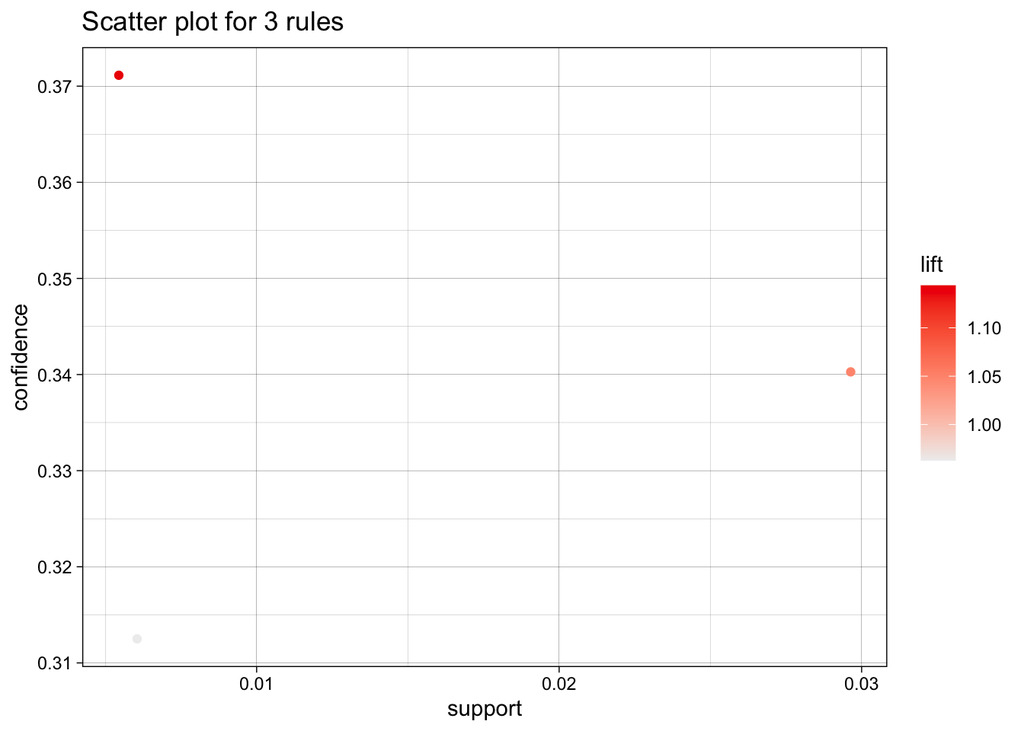

```r
plot(bread_rules, measure=c("support","confidence"), shading="lift")
```

The result was three rules: Jam ==> bread, pastry ==> bread, and tiffin to bread. Jam to bread had the highest confidence, with makes sense intuitively, with the others following closely behind. Pastry to bread had the highest support (.029) indicating that about 2.9% of all transactions contain both Pastry and Bread.

Visually, we see the three rules, and the metrics illustrate how the rules have relatively similar confidence, but only pastry to bread has relatively higher support

I was hoping to capture slightly more rules than 3, so I will consider lowering support in the next trial.

## 5.2 Bread Rules 2:

```r
bread_rules2 <- apriori(transactions,
                       parameter = list(support = 0.002, confidence = 0.3, minlen = 2),
                       appearance = list(rhs = "Bread", default="lhs"))
```

```
## Apriori
##
## Parameter specification:
##  confidence minval smax arem  aval originalSupport maxtime support minlen
##         0.3    0.1    1 none FALSE            TRUE       5   0.002      2
##  maxlen target  ext
##      10  rules TRUE
##
## Algorithmic control:
##  filter tree heap memopt load sort verbose
##     0.1 TRUE TRUE  FALSE TRUE    2    TRUE
##
## Absolute minimum support count: 13
##
## set item appearances ...[1 item(s)] done [0.00s].
## set transactions ...[102 item(s), 6613 transaction(s)] done [0.00s].
## sorting and recoding items ... [46 item(s)] done [0.00s].
## creating transaction tree ... done [0.00s].
## checking subsets of size 1 2 3 4 done [0.00s].
## writing ... [5 rule(s)] done [0.00s].
## creating S4 object  ... done [0.00s].
```

```r
inspect(sort(bread_rules2, by  = "confidence", decreasing = TRUE))
```

```
##     lhs                    rhs     support     confidence coverage    lift
## [1] {Jam}               => {Bread} 0.005443823 0.3711340  0.014668078 1.1436670
## [2] {Jammie Dodgers}    => {Bread} 0.004990171 0.3548387  0.014063209 1.0934522
## [3] {Pastry}            => {Bread} 0.029638591 0.3402778  0.087101164 1.0485820
## [4] {Medialuna, Pastry} => {Bread} 0.002570694 0.3207547  0.008014517 0.9884208
## [5] {Tiffin}            => {Bread} 0.006048692 0.3125000  0.019355814 0.9629835
##     count
## [1]  36
## [2]  33
## [3] 196
## [4]  17
## [5]  40
```

### 5.2.1 Bread Rules 2 Visualization

#### 5.2.1.1 Rules

```r
plot(bread_rules2, method = "graph", engine = "htmlwidget")
```

[interactive chart not shown]

#### 5.2.1.2 Metrics

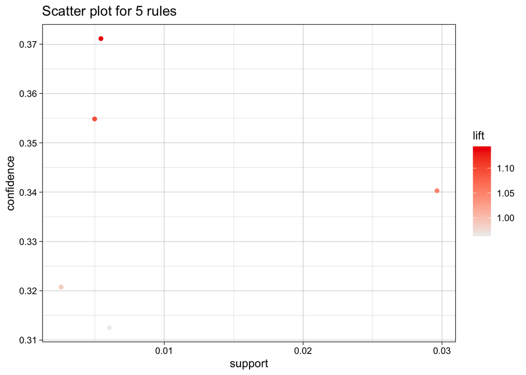

```r
plot(bread_rules2, measure=c("support","confidence"), shading="lift")
```

## 5.3 Final Rule Interpretations:

1. Jam ==> Bread

Customers who buy Jam also buy Bread about 37% of the time. With a lift of 1.14, this indicates a moderate complementary relationship, making Jam a good candidate for bundling or promotion with Bread.

2. Jammie Dodger ==> Bread

Buyers of Jammie Dodger purchase Bread 35% of the time, with a lift of 1.09, showing a slightly stronger than random association. This suggests Jammie Dodger could be promoted to maintain revenue during a price increase.

3. Pastry ==> Bread

Pastry buyers also purchase Bread 34% of the time, and with a lift of 1.05, showing potential association. Given its relatively high support, Pastry is a frequent complement to Bread and a key candidate for promotional strategies.

Customers buying Medialuna purchase Bread about 32% of the time, but the lift of 0.99 indicates the association is slightly weaker than expected by chance. This rule may be considered a secondary option for bundling if stronger combinations are insufficient.

5. Tiffin ==> Bread

Tiffin buyers purchase Bread around 31% of the time, with a lift of 0.96, suggesting a weak association. While less predictive, Tiffin could be used as a backup complement in promotions or bundle deals.

## 5.4 Recommendation

Given the rise in bread prices, it is important to maintain overall revenue by focusing on complementary items that are frequently purchased with bread. Our analysis identifies Jam, Jammie Dodger, and Pastry as the strongest candidates, with confidence between 34–37% and lift above 1. These items show a meaningful association with bread and should be prioritized for bundling or promotional strategies to encourage continued purchase.

Secondary items, such as Medialuna and Tiffin, have moderate confidence but lower lift. While they are less predictive, they could serve as backup options in promotions if the primary items fail to sustain demand.

### 5.4.1 Practical Solutions:

1.Leverage complementary items by promoting items that are frequently bought with bread (Jam, Pastry, Jammie Dodger).If customers still buy bread, they are likely to buy these too, which boosts overall basket value.

2.For high-confidence/lift items (Jam, Pastry, Jammie Dodger), consider bundling with bread at a slight discount or increasing their price slightly if demand is robust, though it is unlikely it would be, especially if bread is expensive.

3.Increase demand through promotion by using in-store displays, “combo deals,” or marketing to encourage purchase of these complements, potentially even those with weaker relationships to bread.

# 6 Scenario 3:

The café has just introduced a new product, tea, and wants to maximize revenue while increasing customer awareness. Using association rules, we can identify which existing items are most frequently purchased alongside the new product, highlighting opportunities for bundling or promotions.

## 6.1 Analyis

We will begin by exploring tea rules with tea on the right hand side, to see which existing items lead to tea purchases.

### 6.1.1 Tea Rules 1

```r
tea_rules1 <- apriori(transactions,
                       parameter = list(support = 0.004, confidence = 0.2, minlen = 2),
                       appearance = list(rhs = "Tea", default="lhs"))
```

```
## Apriori
##
## Parameter specification:
##  confidence minval smax arem  aval originalSupport maxtime support minlen
##         0.2    0.1    1 none FALSE            TRUE       5   0.004      2
##  maxlen target  ext
##      10  rules TRUE
##
## Algorithmic control:
##  filter tree heap memopt load sort verbose
##     0.1 TRUE TRUE  FALSE TRUE    2    TRUE
##
## Absolute minimum support count: 26
##
## set item appearances ...[1 item(s)] done [0.00s].
## set transactions ...[102 item(s), 6613 transaction(s)] done [0.00s].
## sorting and recoding items ... [40 item(s)] done [0.00s].
## creating transaction tree ... done [0.00s].
## checking subsets of size 1 2 3 4 done [0.00s].
## writing ... [6 rule(s)] done [0.00s].
## creating S4 object  ... done [0.00s].
```

```r
inspect(tea_rules1)
```

```
##     lhs                 rhs   support     confidence coverage   lift     count
## [1] {Tiffin}         => {Tea} 0.004385302 0.2265625  0.01935581 1.592197  29
## [2] {Spanish Brunch} => {Tea} 0.005443823 0.2448980  0.02222894 1.721052  36
## [3] {Scone}          => {Tea} 0.008165734 0.2400000  0.03402389 1.686631  54
## [4] {Soup}           => {Tea} 0.008921821 0.2543103  0.03508241 1.787199  59
## [5] {Cake}           => {Tea} 0.026160593 0.2492795  0.10494481 1.751844 173
## [6] {Bread, Cake}    => {Tea} 0.005141388 0.2207792  0.02328746 1.551555  34
```

### 6.1.2 Visualize

#### 6.1.2.1 Rules

```r
plot(tea_rules1, method = "graph", engine = "htmlwidget")
```

[interactive chart not shown]

#### 6.1.2.2 Metrics

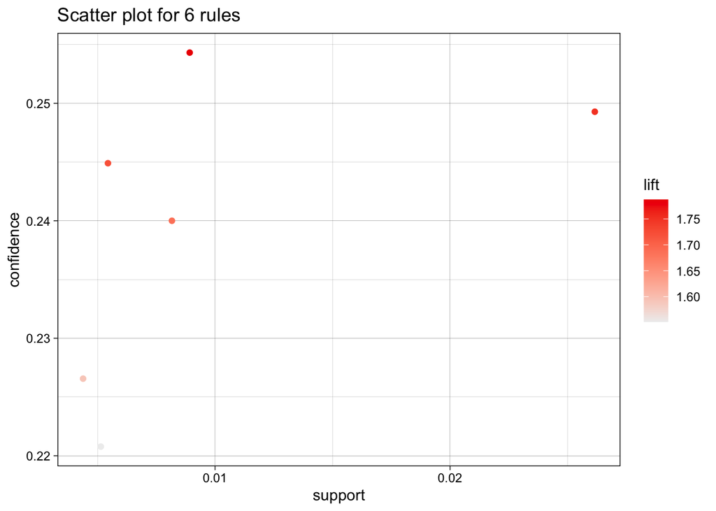

```r
plot(tea_rules1, measure=c("support","confidence"), shading="lift")
```

Since Tea is a mid-frequency item in the dataset, I adjusted the support and confidence thresholds to generate meaningful rules. Initially, I set support at 0.005 and confidence at 0.3, but no rules were produced. Lowering support slightly to 0.004 while keeping confidence at 0.3 still yielded no rules. Finally, maintaining support at 0.004 and reducing confidence to 0.2 produced six rules, providing a decent number of observations for analysis.

Now that I have six rules with support 0.004 and confidence 0.2, I will try lowering the support threshold further to see if additional associations emerge. This may reveal less frequent but potentially valuable item pairings with Tea, helping identify opportunities for promotions, bundling, or pricing strategies.

### 6.1.3 Tea Rules 2

```r
tea_rules2 <- apriori(transactions,
                       parameter = list(support = 0.002, confidence = 0.2, minlen = 2),
                       appearance = list(rhs = "Tea", default="lhs"))
```

```
## Apriori
##
## Parameter specification:
##  confidence minval smax arem  aval originalSupport maxtime support minlen
##         0.2    0.1    1 none FALSE            TRUE       5   0.002      2
##  maxlen target  ext
##      10  rules TRUE
##
## Algorithmic control:
##  filter tree heap memopt load sort verbose
##     0.1 TRUE TRUE  FALSE TRUE    2    TRUE
##
## Absolute minimum support count: 13
##
## set item appearances ...[1 item(s)] done [0.00s].
## set transactions ...[102 item(s), 6613 transaction(s)] done [0.00s].
## sorting and recoding items ... [46 item(s)] done [0.00s].
## creating transaction tree ... done [0.00s].
## checking subsets of size 1 2 3 4 done [0.00s].
## writing ... [11 rule(s)] done [0.00s].
## creating S4 object  ... done [0.00s].
```

```r
inspect(sort(tea_rules2, by = "lift", decreasing = TRUE))
```

```
##      lhs                      rhs   support     confidence coverage    lift
## [1]  {Soup}                => {Tea} 0.008921821 0.2543103  0.035082413 1.787199
## [2]  {Cake}                => {Tea} 0.026160593 0.2492795  0.104944806 1.751844
## [3]  {Chicken Stew}        => {Tea} 0.003629215 0.2474227  0.014668078 1.738795
## [4]  {Spanish Brunch}      => {Tea} 0.005443823 0.2448980  0.022228943 1.721052
## [5]  {Scone}               => {Tea} 0.008165734 0.2400000  0.034023892 1.686631
## [6]  {Tiffin}              => {Tea} 0.004385302 0.2265625  0.019355814 1.592197
## [7]  {Bread, Cake}         => {Tea} 0.005141388 0.2207792  0.023287464 1.551555
## [8]  {Hearty & Seasonal}   => {Tea} 0.002117042 0.2121212  0.009980342 1.490709
## [9]  {Cake, Hot chocolate} => {Tea} 0.002117042 0.2058824  0.010282776 1.446865
## [10] {Coffee, Scone}       => {Tea} 0.003780432 0.2049180  0.018448511 1.440088
## [11] {Coffee, Tiffin}      => {Tea} 0.002117042 0.2000000  0.010585211 1.405526
##      count
## [1]   59
## [2]  173
## [3]   24
## [4]   36
## [5]   54
## [6]   29
## [7]   34
## [8]   14
## [9]   14
## [10]  25
## [11]  14
```

### 6.1.4 Visualize

#### 6.1.4.1 Rules

```r
plot(tea_rules2, method = "graph", engine = "htmlwidget")
```

[interactive chart not shown]

#### 6.1.4.2 Metrics

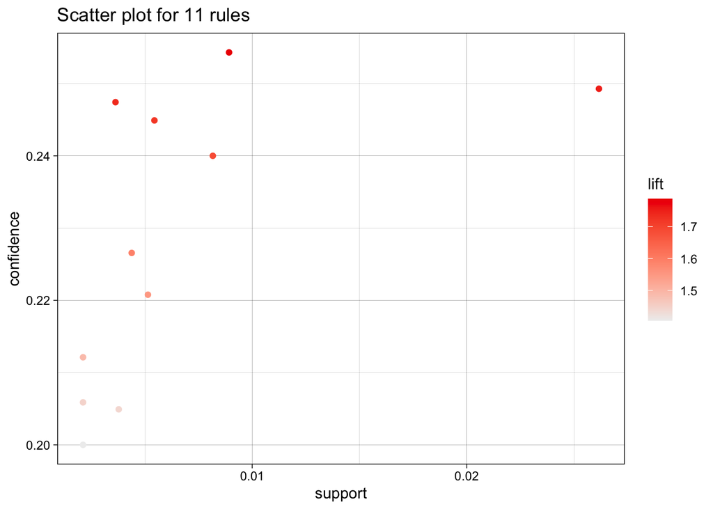

```r
plot(tea_rules2, measure=c("support","confidence"), shading="lift")
```

Results:

1: Customers who purchase soup buy tea 25% of the time, and the lift of 1.79 shows they are almost 80% more likely to buy tea than the average shopper. This is the strongest predictor of tea purchases in the dataset.

2: The second rule also shows about 25% confidence, but with much higher support, meaning cake is both popular and strongly associated with choosing tea. Its lift of 1.75 confirms this item is a core complement to tea.

## 6.2 Analysis 2

Now, we will look at association rules with tea on the left had side, to see which purchases the new product may drive!

### 6.2.1 Tea Rules 3

```r
tea_rules3 <- apriori(transactions,
                       parameter = list(support = 0.004, confidence = 0.2, minlen = 2),
                       appearance = list(lhs = "Tea", default="rhs"))
```

```
## Apriori
##
## Parameter specification:
##  confidence minval smax arem  aval originalSupport maxtime support minlen
##         0.2    0.1    1 none FALSE            TRUE       5   0.004      2
##  maxlen target  ext
##      10  rules TRUE
##
## Algorithmic control:
##  filter tree heap memopt load sort verbose
##     0.1 TRUE TRUE  FALSE TRUE    2    TRUE
##
## Absolute minimum support count: 26
##
## set item appearances ...[1 item(s)] done [0.00s].
## set transactions ...[102 item(s), 6613 transaction(s)] done [0.00s].
## sorting and recoding items ... [40 item(s)] done [0.00s].
## creating transaction tree ... done [0.00s].
## checking subsets of size 1 2 done [0.00s].
## writing ... [2 rule(s)] done [0.00s].
## creating S4 object  ... done [0.00s].
```

```r
inspect(tea_rules3)
```

```
##     lhs      rhs      support    confidence coverage  lift      count
## [1] {Tea} => {Bread}  0.02948737 0.2072264  0.1422955 0.6385778 195
## [2] {Tea} => {Coffee} 0.05171632 0.3634431  0.1422955 0.7539051 342
```

### 6.2.2 Tea Rules 3 Visualization

#### 6.2.2.1 Rules

```r
plot(tea_rules3, method = "graph", engine = "htmlwidget")
```

[interactive chart not shown]

#### 6.2.2.2 Metrics

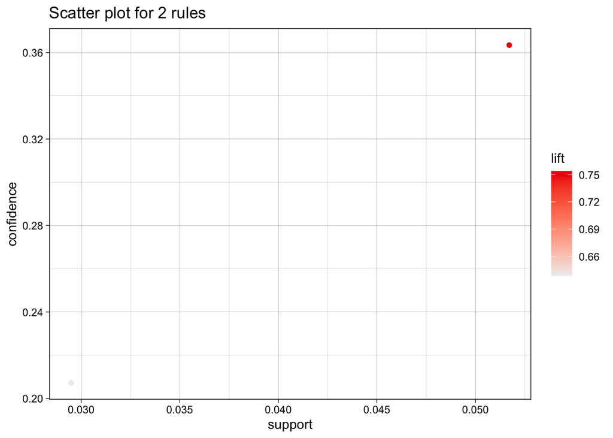

```r
plot(tea_rules3, measure=c("support","confidence"), shading="lift")
```

Results:

This may indicate that there could be something unique about those who buy tea.

To look for more rules that potentially have higher lift, yet lower confidence and support, I will decrease their thresholds and asses their results.

### 6.2.3 Tea Rules 4

```r
tea_rules4 <- apriori(transactions,
                       parameter = list(support = 0.002, confidence = 0.1, minlen = 2),
                       appearance = list(lhs = "Tea", default="rhs"))
```

```
## Apriori
##
## Parameter specification:
##  confidence minval smax arem  aval originalSupport maxtime support minlen
##         0.1    0.1    1 none FALSE            TRUE       5   0.002      2
##  maxlen target  ext
##      10  rules TRUE
##
## Algorithmic control:
##  filter tree heap memopt load sort verbose
##     0.1 TRUE TRUE  FALSE TRUE    2    TRUE
##
## Absolute minimum support count: 13
##
## set item appearances ...[1 item(s)] done [0.00s].
## set transactions ...[102 item(s), 6613 transaction(s)] done [0.00s].
## sorting and recoding items ... [46 item(s)] done [0.00s].
## creating transaction tree ... done [0.00s].
## checking subsets of size 1 2 done [0.00s].
## writing ... [3 rule(s)] done [0.00s].
## creating S4 object  ... done [0.00s].
```

```r
inspect(tea_rules4)
```

```
##     lhs      rhs      support    confidence coverage  lift      count
## [1] {Tea} => {Cake}   0.02616059 0.1838470  0.1422955 1.7518444 173
## [2] {Tea} => {Bread}  0.02948737 0.2072264  0.1422955 0.6385778 195
## [3] {Tea} => {Coffee} 0.05171632 0.3634431  0.1422955 0.7539051 342
```

By lowering support and confidence thresholds, I only found one more rule, tea ==> cake, it may have low confidence and support, but it has a high lift of 1.75!

## 6.3 Recommendations and Insights

Because Soup, Cake, and Chicken Stew are the strongest predictors of tea purchases, the café should use these items to introduce and promote the new tea product. Pairing tea with these items in small bundle deals or point-of-sale promotions can increase visibility and encourage customers who already buy these foods to try tea. This approach raises awareness, boosts sales of the new product, and helps grow revenue with minimal operational changes.

This may mean that tea buyers appear to be “single-purpose” customers who don’t build large baskets, and that their preferences may be fundamentally different that the typical coffee customer at the café.

Thus, we recommend strategic bundling such as “Afternoon Tea” combos (Tea + Scone + Cake) at attractive pricing to increase basket size among this smaller-spending segment. We also recomment potentially expanding the tea menu. Since tea attracts a distinct customer base, consider expanding tea varieties or tea-specific snacks to capture more revenue from this underserved segment.

# 7 Case Conclusion

Using association rule mining, we analyzed customer purchasing patterns to address three critical business challenges: a coffee surplus requiring price reductions, a bread shortage necessitating price increases, and the introduction of tea as a new product. Our analysis provides actionable strategies for maintaining profitability despite changing market conditions.

## 7.1 Key Findings

Coffee Surplus: Strong associations exist between coffee and specific food items, with Toast showing the highest confidence (72%). These complementary relationships provide clear opportunities to offset lost coffee revenue.

Bread Shortage: Jam, Jammie Dodger, and Pastry are the strongest predictors of bread purchases, with positive lift values indicating genuine complementary relationships rather than random co-occurrence.

Tea Introduction: Tea customers represent a distinct segment with different purchasing behavior. Tea functions as a coffee substitute (negative associations with both coffee and bread) but shows strong pairing potential with Cake (lift 1.75).

## 7.2 Strategic Recommendations

Dynamic Pricing: Strategically increase prices on high-confidence coffee complements (Toast, Spanish Brunch, Cake) to offset coffee revenue losses while maintaining customer value perception through familiar pairings.

Targeted Bundling: Create product bundles that leverage strong associations, such as bread and jam and tea with cake or soup, to increase average basket size and encourage purchases of complementary items.

Segment-Based Strategy: Market tea independently with its own complementary items rather than cross-selling traditional café staples, recognizing that tea attracts a fundamentally different customer base.

Product Placement Optimization: Position complementary items together to capitalize on discovered associations and facilitate natural purchasing patterns.

## 7.3 Conclusion

Faced with simultaneous economic pressures requiring price cuts, price hikes, and new product launches, the café manager now has a data-driven framework for navigating these competing demands. Association rule mining reveals which price adjustments customers will tolerate, which products can offset revenue losses, and where bundling creates value. This transforms difficult gut-feel decisions into strategic choices backed by actual customer behavior, enabling the manager to protect profitability while maintaining customer satisfaction despite external market volatility.